# Problem set grade summaries

## Problem set 1

Descriptive statistics of scores for Problem set 1:

- Mean: 7.84
- Median: 8
- Standard deviation: 1.55
- Standard error: 0.32

Here is the distribution of scores:

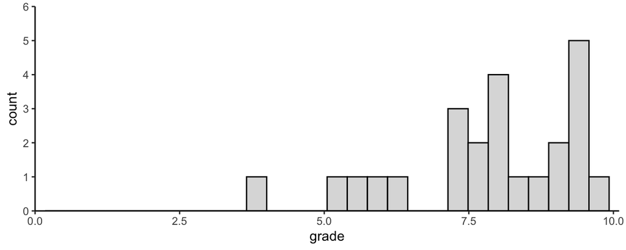

### Points off by question

| Question | Average point deduction (%) |
| --- | --- |
| 6.1 | 38.00 |
| 9 | 34.00 |
| 5.5 | 32.80 |
| 7.2 | 28.80 |
| 5.4 | 28.00 |
| 8 | 28.00 |
| 7.1 | 24.80 |
| 10 | 22.40 |
| 3 | 22.40 |
| 1 | 20.00 |
| 4.1 | 13.92 |
| 5.1 | 11.84 |
| 4.4 | 9.92 |
| 5.2 | 6.56 |
| 2 | 6.00 |
| 5.3 | 4.00 |
| 4.3 | 3.84 |
| 4.2 | 3.84 |
| 6.3 | 1.92 |

### Points off by the type of mistake

| Type of mistake | Average points off |
| --- | --- |
| functions you may use in this assignment | 1.05 |
| incorrect answer | 0.32 |
| file name | 0.20 |
| unapproved assignment | 0.16 |
| added violation | 0.15 |
| did not answer | 0.12 |
| missed violation | 0.07 |

### Points of by mistake

| Mistake | n_mistakes | total_points_off | Average points off |
| --- | --- | --- | --- |
| functions you may use in this assignment | 94 | 26.21 | 1.05 |
| unapproved assignment | 20 | 3.97 | 0.16 |
| did not answer | 5 | 3.00 | 0.12 |
| last name should precede first name within the naming convention | 3 | 3.00 | 0.12 |
| did not produce the requested result | 11 | 2.60 | 0.10 |
| missing argument in function | 5 | 2.50 | 0.10 |
| no line break after assignment | 8 | 1.60 | 0.06 |
| removed comment | 7 | 1.40 | 0.06 |
| did not return the requested object | 7 | 1.51 | 0.06 |
| was not in snake case | 4 | 1.00 | 0.04 |
| additional characters in naming convention | 2 | 1.00 | 0.04 |
| absolute file path | 2 | 1.00 | 0.04 |

## Problem set 2

Descriptive statistics of scores for Problem set 2:

- Mean: 8.14
- Median: 8.75
- Standard deviation: 1.72
- Standard error: 0.33

Here is the distribution of scores:

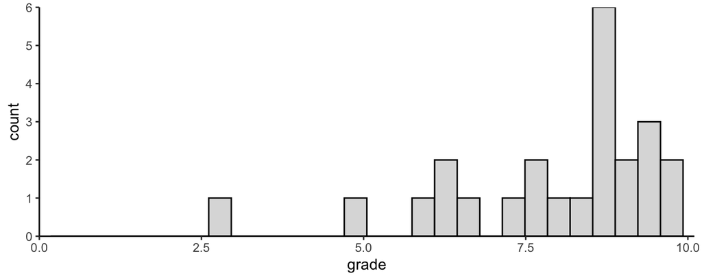

### Points off by question

| Question | Average point deduction (%) |
| --- | --- |
| 8 | 33.33 |
| 6 | 28.52 |
| 5 | 17.96 |
| 7 | 17.28 |
| 3 | 9.26 |
| 4 | 4.81 |
| 1 | 2.78 |

### Points off by the type of mistake

| Type of mistake | Average points off |
| --- | --- |
| functions you may use in this assignment | 1.17 |
| incorrect answer | 0.44 |
| missed violation | 0.20 |
| file name | 0.03 |
| unapproved assignment | 0.02 |
| added violation | 0.01 |
| indentation | 0.00 |

### Points of by mistake

| Mistake | n_mistakes | total_points_off | Average points off |
| --- | --- | --- | --- |
| functions you may use in this assignment | 38 | 31.50 | 1.17 |
| missed grouping variable | 7 | 3.50 | 0.13 |
| three or more arguments on the same line | 9 | 1.80 | 0.07 |
| infix functions should have a leading and trailing space | 7 | 1.80 | 0.07 |
| did not produce the requested result | 2 | 2.00 | 0.07 |
| broken pipe | 2 | 1.50 | 0.06 |
| code will not run as written | 1 | 1.00 | 0.04 |
| did not return the requested object | 8 | 0.80 | 0.03 |
| warning message | 3 | 0.75 | 0.03 |
| space after comma | 4 | 0.80 | 0.03 |

## Problem set 3

Descriptive statistics of scores for Problem set 3:

- Mean: 8.45
- Median: 8.69
- Standard deviation: 1.27
- Standard error: 0.25

Here is the distribution of scores:

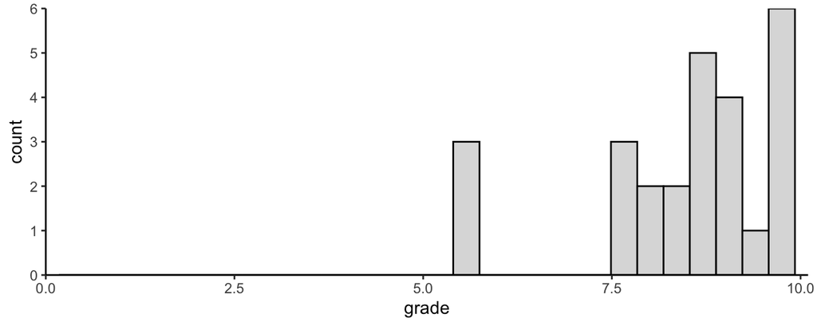

### Points off by question

| Question | Average point deduction (%) |
| --- | --- |
| 7.1 | 59.62 |
| 6.1 | 40.77 |
| 5.2 | 30.38 |
| 5.6 | 23.08 |
| 5.1 | 17.31 |
| 7.2 | 15.38 |
| 6.2 | 11.54 |
| 4.1 | 11.15 |
| 6.3 | 10.00 |
| 7.3 | 10.00 |
| 5.5 | 8.46 |
| 4.4 | 7.69 |
| 4.3 | 7.31 |
| 5.4 | 6.92 |
| 4.2 | 6.54 |
| 4.5 | 4.23 |
| 2 | 4.23 |
| 4.6 | 3.46 |
| 5.3 | 1.92 |
| 4.7 | 1.92 |
| 3 | 1.54 |
| 5.7 | 1.15 |
| 5.8 | 0.77 |
| 1 | 0.38 |

### Points off by the type of mistake

| Type of mistake | Average points off |
| --- | --- |
| incorrect answer | 0.80 |
| functions you may use in this assignment | 0.39 |
| unapproved assignment | 0.25 |
| code formatting | 0.11 |
| file name | 0.00 |

### Points off by mistake

| Mistake | n_mistakes | total_points_off | Average points off |
| --- | --- | --- | --- |
| unapproved assignment | 22 | 6.625 | 0.25 |
| missing answer | 12 | 6.000 | 0.23 |
| did not summarize by primary key | 17 | 4.250 | 0.16 |
| group_by() | 8 | 3.000 | 0.12 |
| did not subset to brood X cicada | 10 | 2.500 | 0.10 |
| as.tibble() | 6 | 2.500 | 0.10 |
| mutating rather than filtering join | 6 | 1.500 | 0.06 |
| left_join() | 5 | 1.500 | 0.06 |
| incorrect file path | 9 | 1.125 | 0.04 |
| code will not run | 4 | 1.000 | 0.04 |
| did not subset to state | 2 | 1.000 | 0.04 |

| student_name_last | grade |
| --- | --- |
| ajagun | 9.700 |
| alegre | 5.650 |
| christensen | 8.900 |
| cruz | 9.325 |
| de boer | 9.725 |
| gorosabel | 8.625 |
| guervil | 8.100 |
| johnson | 8.850 |
| lee | 9.725 |
| magagula | 5.575 |
| marthens | 8.300 |
| mccarthy | 8.925 |
| mogensen | 9.875 |
| peyton | 9.175 |
| pinto | 8.675 |
| puishys | 9.675 |
| pulido | 8.700 |
| ruhs | 8.300 |
| souza | 7.700 |
| stevenson | 7.525 |
| tingle | 9.175 |
| treat | 7.575 |
| tucker | 8.625 |
| valli | 5.425 |
| waldrep | 9.725 |
| zeitz | 8.050 |

## Problem set 4

Descriptive statistics of scores for Problem set 4:

- Mean: 8.54
- Median: 9.12
- Standard deviation: 1.49
- Standard error: 0.33

Here is the distribution of scores:

[figure not shown]

### Points off by question

| Question | Average point deduction (%) |
| --- | --- |
| 10.3 | 58.5 |
| 4.4 | 55.5 |
| 8.1 | 37.0 |
| 10.2 | 33.5 |
| 10.1 | 26.0 |
| 5.1 | 25.5 |
| 4.3 | 20.0 |
| 5.3 | 19.0 |
| 8.2 | 16.0 |
| 4.4 | 11.1 |
| 5.5 | 11.0 |
| 5.4 | 10.0 |
| 10.4 | 10.0 |
| 3.1 | 8.5 |
| 4.2 | 8.0 |
| 3.3 | 7.5 |
| 4.1 | 7.5 |
| 7.1 | 7.0 |
| 7.2 | 5.5 |
| 10 | 5.0 |
| 9 | 5.0 |
| 6.2 | 3.0 |
| 2 | 1.5 |
| 6.3 | 1.5 |
| 6.4 | 1.5 |
| 3.4 | 1.0 |
| 4.1 | 0.9 |
| 5.6 | 0.5 |
| 7.3 | 0.5 |
| 1 | 0.5 |
| 4.5 | 0.0 |
| 6.5 | 0.0 |
| 5.2 | 0.0 |
| 3.2 | 0.0 |
| 6.1 | 0.0 |

### Points off by the type of mistake

| Type of mistake | Average points off |
| --- | --- |
| incorrect answer | 0.86 |
| functions you may use in this assignment | 0.36 |
| unapproved assignment | 0.13 |
| code formatting | 0.06 |
| code parsimony | 0.04 |
| file name | 0.00 |

### Points off by mistake

| Mistake | n_mistakes | total_points_off | Average points off |
| --- | --- | --- | --- |
| missing answer | 12 | 5.50000 | 0.28 |
| unapproved assignment | 11 | 2.62500 | 0.13 |
| $ | 10 | 2.00000 | 0.10 |
| order of objects in st_join() | 6 | 1.50000 | 0.07 |
| did not map individual homicides | 6 | 1.37500 | 0.07 |
| did not filter homicides | 5 | 1.12500 | 0.06 |
| incorrect CRS | 2 | 1.00000 | 0.05 |
| [[...]] | 6 | 1.03125 | 0.05 |
| incorrect fill color | 1 | 1.00000 | 0.05 |
| incorrect map() | 1 | 1.00000 | 0.05 |

| student_name_last | grade |
| --- | --- |
| ajagun | 9.7550 |
| alegre | 6.6200 |
| cruz | 8.8000 |
| de boer | 9.1250 |
| guervil | 9.7500 |
| johnson | 9.9000 |
| lee | 9.1100 |
| magagula | 7.1750 |
| mccarthy | 9.4750 |
| mogensen | 9.6400 |
| peyton | 9.6250 |
| puishys | 9.6250 |
| pulido | 6.9350 |
| ruhs | 8.5450 |
| souza | 5.8599 |
| stevenson | 7.5450 |
| tingle | 9.9850 |
| treat | 8.6900 |
| tucker | 4.9700 |
| waldrep | 9.7000 |

## Problem set 5

Descriptive statistics of scores for Problem set 5:

- Mean: 8.06
- Median: 8.46
- Standard deviation: 1.75
- Standard error: 0.37

Here is the distribution of scores:

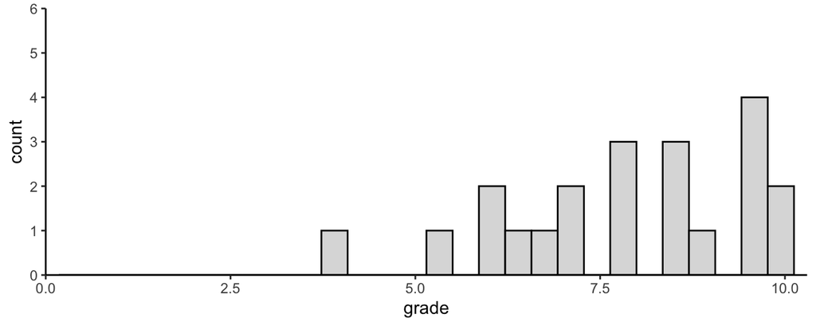

### Points off by question

| Question | Average point deduction (%) |
| --- | --- |
| 8.2 | 55.65 |
| 9.4 | 53.91 |
| 7.2 | 45.87 |
| 8.3 | 44.78 |
| 9.3 | 34.35 |
| 9.1 | 30.87 |
| 9.2 | 28.26 |
| 7.1 | 24.78 |
| 6.2 | 19.13 |
| 5.2 | 16.96 |
| 5.3 | 13.48 |
| 8.1 | 13.04 |
| 4.2 | 11.30 |
| 5.1 | 8.70 |
| 3.3 | 7.61 |
| 3.5 | 6.96 |
| 4.3 | 6.96 |
| 6.1 | 5.22 |
| 3.3 | 5.07 |
| 3.1 | 4.78 |
| 6 | 4.35 |
| 4.4 | 4.35 |
| 5.4 | 3.91 |
| 3.2 | 1.74 |
| 3.4 | 1.30 |
| 4.1 | 1.30 |
| 2 | 0.43 |
| 2.1 | 0.43 |
| 2.2 | 0.43 |
| 9.5 | -Inf |

### Points off by the type of mistake

| Type of mistake | Average points off |
| --- | --- |
| incorrect answer | 0.84 |
| functions you may use in this assignment | 0.60 |
| unapproved assignment | 0.32 |
| code formatting | 0.26 |
| code parsimony | 0.09 |
| extra credit | -0.18 |

### Points off by mistake

| Mistake | n_mistakes | total_points_off | Average points off |
| --- | --- | --- | --- |
| missing answer | 24 | 9.800 | 0.43 |
| unapproved assignment | 25 | 7.475 | 0.32 |
| indentation is off | 73 | 2.590 | 0.11 |
| did not color by census tract | 2 | 2.000 | 0.09 |
| [...] | 5 | 2.083 | 0.09 |
| group_by() | 9 | 1.741 | 0.08 |
| select() | 9 | 1.793 | 0.08 |
| terra::mask() | 6 | 1.500 | 0.07 |
| as.numeric() | 10 | 1.550 | 0.07 |
| maintain one line between code blocks and comments | 45 | 1.265 | 0.06 |

| student_name_last | grade |
| --- | --- |
| ajagun | 9.440 |
| beath | 5.970 |
| christensen | 7.765 |
| cruz | 9.585 |
| de boer | 10.050 |
| gorosabel | 6.540 |
| guervil | 5.265 |
| johnson | 9.690 |
| lee | 10.150 |
| magagula | 3.785 |
| mccarthy | 9.430 |
| mogensen | 9.030 |
| peyton | 8.470 |
| pinto | 6.865 |
| puishys | 10.250 |
| pulido | 7.825 |
| ruhs | 6.100 |
| souza | 7.805 |
| tingle | 10.100 |
| treat | 6.985 |
| tucker | 8.465 |
| waldrep | 8.600 |
| zeitz | 7.200 |

## Problem set 6

Descriptive statistics of scores for Problem set 6:

- Mean: 7.99
- Median: 8.66
- Standard deviation: 2.52
- Standard error: 0.58

Here is the distribution of scores:

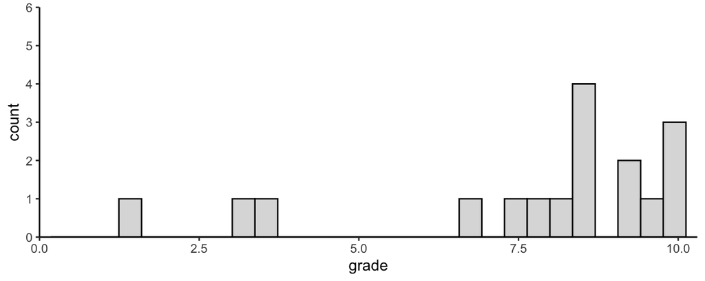

### Points off by question

| Question | Average point deduction (%) |
| --- | --- |
| 4.1 | 47.89 |
| 8.5 | 46.67 |
| 8.3 | 46.32 |
| 7.2.3 | 40.53 |
| 9.2 | 36.84 |
| 7.2.1 | 34.74 |
| 8.4 | 34.74 |
| 9.3 | 32.63 |
| 8.2 | 32.63 |
| 6.2 | 32.37 |
| 8.1 | 27.89 |
| 7.1.1 | 23.82 |
| 9.1 | 22.63 |
| 5.1 | 22.63 |
| 7.2.2 | 21.97 |
| 6.2 | 21.58 |
| 8.6 | 21.05 |
| 7.2.3 | 20.26 |
| 4.2 | 17.89 |
| 8.8 | 17.89 |
| 6.5 | 16.32 |
| 5.6 | 16.32 |
| 6.1 | 14.74 |
| 7.1.2 | 12.11 |
| 7.2.4 | 11.58 |
| 8.7 | 11.58 |
| 5.3 | 11.58 |
| 5.4 | 11.58 |
| 5.2 | 11.05 |
| 7.3 | 11.05 |
| 2.3 | 11.05 |
| 5.5 | 11.05 |
| 9.0 | 9.79 |
| 4.3 | 8.42 |
| 3.1 | 8.42 |
| 6.4 | 7.37 |
| 4.4 | 6.32 |
| 4.5 | 6.32 |
| 5.7 | 6.32 |
| 5.8 | 6.32 |
| 3.3 | 3.16 |
| 1 | 2.63 |
| 3.2 | 2.63 |
| 3.4 | 1.05 |
| 2.1 | 0.53 |
| 2.2 | 0.53 |
| 6.3 | 0.53 |
| 9.4 | -Inf |

### Points off by the type of mistake

| Type of mistake | Average points off |
| --- | --- |
| incorrect answer | 1.48 |
| functions you may use in this assignment | 0.25 |
| code formatting | 0.20 |
| unapproved assignment | 0.14 |
| code parsimony | 0.07 |
| extra credit | -0.13 |

### Points off by mistake

| Mistake | n_mistakes | total_points_off | Average points off |
| --- | --- | --- | --- |
| missing answer | 68 | 16.300 | 0.86 |
| unapproved assignment | 16 | 2.675 | 0.14 |
| indentation is off | 49 | 1.655 | 0.09 |
| did not extract values from raster | 5 | 1.200 | 0.06 |
| did not convert to a factor | 4 | 1.200 | 0.06 |
| missing titles | 4 | 1.100 | 0.06 |
| did not remove NA values | 5 | 1.000 | 0.05 |
| did not specify boundary arguments | 5 | 1.000 | 0.05 |
| & | 5 | 1.000 | 0.05 |
| maintain one line between code blocks and comments | 33 | 0.510 | 0.03 |
| three or more arguments on the same line | 18 | 0.620 | 0.03 |
| did not use a forcats function | 2 | 0.500 | 0.03 |
| incorrect boundary values | 3 | 0.500 | 0.03 |
| right = TRUE | 3 | 0.600 | 0.03 |
| did not use the same color palette | 2 | 0.500 | 0.03 |

| student_name_last | grade |
| --- | --- |
| ajagun | 8.670 |
| beath | 8.320 |
| christensen | 1.420 |
| cruz | 9.740 |
| de boer | 9.950 |
| guervil | 8.660 |
| johnson | 9.295 |
| lee | 9.950 |
| magagula | 3.195 |
| marthens | 6.920 |
| mccarthy | 9.130 |
| mogensen | 10.140 |
| peyton | 8.540 |
| puishys | 9.990 |
| souza | 3.700 |
| tingle | 10.190 |
| treat | 7.625 |
| tucker | 8.390 |
| zeitz | 7.950 |

## Problem set 7

Descriptive statistics of scores for Problem set 7:

- Mean: 9.04
- Median: 9.57
- Standard deviation: 1.85
- Standard error: 0.56

Here is the distribution of scores:

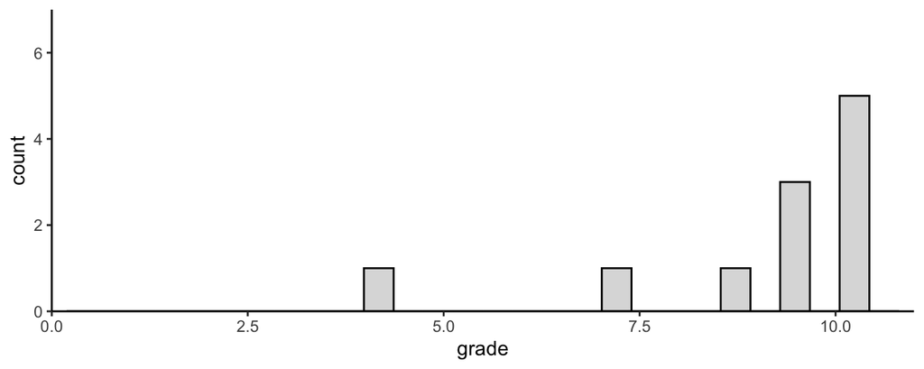

### Points off by question

| Question | Average point deduction (%) |
| --- | --- |
| 6.1 | 31.21 |
| 9 | 24.09 |
| 4.4 | 23.64 |
| 5 | 18.64 |
| 8.2 | 18.18 |
| 8.1 | 17.27 |
| 7.5 | 15.45 |
| 10 | 13.41 |
| 3.4 | 10.00 |
| 3.1 | 10.00 |
| 4.1 | 9.09 |
| 6.2 | 9.09 |
| 7.3 | 6.36 |
| 7.4 | 6.36 |
| 4.2 | 4.55 |
| 3.2 | 2.73 |
| 7.1 | 1.82 |
| 2.3 | 0.91 |
| 7.2 | 0.91 |
| 8.3 | -Inf |
| 11 | -Inf |

### Points off by the type of mistake

| Type of mistake | Average points off |
| --- | --- |
| incorrect answer | 0.64 |
| unapproved assignment | 0.25 |
| code formatting | 0.14 |
| functions you may use in this assignment | 0.12 |
| code parsimony | 0.12 |
| extra credit | -0.31 |

### Points off by mistake

| Mistake | n_mistakes | total_points_off | Average points off |
| --- | --- | --- | --- |
| missing answer | 5 | 3.750 | 0.34 |
| unapproved assignment | 9 | 2.700 | 0.25 |
| [[...]] | 4 | 0.725 | 0.07 |
| maintain one line between code blocks and comments | 13 | 0.650 | 0.06 |
| single space between hashtag and comment | 13 | 0.525 | 0.05 |
| did not include elevation | 2 | 0.500 | 0.05 |
| did not calculate hillshade | 1 | 0.500 | 0.05 |
| direct function call | 10 | 0.460 | 0.04 |
| legend.outside = TRUE | 9 | 0.465 | 0.04 |
| incorrect description | 2 | 0.375 | 0.03 |
| st_sf() | 1 | 0.375 | 0.03 |
| did not convert to a shapefile | 1 | 0.375 | 0.03 |
| did not classify by temperature | 1 | 0.375 | 0.03 |

| student_name_last | grade |
| --- | --- |
| ajagun | 10.075 |
| beath | 9.330 |
| cruz | 10.095 |
| de boer | 10.185 |
| lee | 10.375 |
| mccarthy | 9.575 |
| mogensen | 9.525 |
| souza | 4.200 |
| stevenson | 7.175 |
| treat | 8.730 |
| waldrep | 10.175 |